# Data preprocessing and Visualisaton for Poverty Dataset

18PCSA102

2/2/2020

### RECODING AND EXCLUDING VALUES

```r
library(Hmisc)
```

```r
library(vioplot)
library(vcd)
library(sqldf)
library(reshape)
library(plotrix)

#Attaching dataset
dataset<-read.csv(file.choose(),header=TRUE)
attach(dataset)
dataset<-na.omit(dataset)

#Basic functions
names(dataset)
```

```
##  [1] "row_id"
##  [2] "country_id"
##  [3] "is_urban"
##  [4] "age"
##  [5] "Gender"
##  [6] "married"
##  [7] "religion"
##  [8] "relationship_to_hh_head"
##  [9] "education_level"
## [10] "literacy"
## [11] "employed_last_year"
## [12] "employment_category_last_year"
## [13] "employment_type_last_year"
## [14] "share_hh_income_provided"
## [15] "income_livestock_last_year"
```

[output cut: 21 more lines]

```r
head(dataset)
```

```
##   row_id country_id is_urban age Gender married religion
## 2      1          C    FALSE  40   male    TRUE        P
## 3      2          I    FALSE  35 female    TRUE        Q
## 4      3          I     TRUE  19 female   FALSE        Q
## 5      4          A    FALSE  61 female    TRUE        Q
## 6      5          A     TRUE  16 female   FALSE        Q
## 7      6          F    FALSE  40   male    TRUE        Q
##   relationship_to_hh_head education_level literacy employed_last_year
## 2                    Head               0     TRUE               TRUE
## 3                  Spouse               1    FALSE              FALSE
## 4            Son/Daughter               3     TRUE               TRUE
## 5           Father/Mother               0    FALSE              FALSE
## 6            Son/Daughter               2     TRUE              FALSE
## 7                    Head               0    FALSE               TRUE
##   employment_category_last_year employment_type_last_year
```

[output cut: 69 more lines]

```r
tail(dataset)
```

```
##      row_id country_id is_urban age Gender married religion
## 8394   8393          D     TRUE  40   male    TRUE        X
## 8395   8394          F    FALSE  35   male    TRUE        Q
## 8396   8395          G     TRUE  63   male    TRUE        X
## 8397   8396          J    FALSE  59   male   FALSE        X
## 8399   8398          F     TRUE  32   male    TRUE        X
## 8400   8399          A    FALSE  26 female    TRUE        Q
##      relationship_to_hh_head education_level literacy employed_last_year
## 8394                    Head               1     TRUE              FALSE
## 8395                    Head               1    FALSE              FALSE
## 8396                    Head               1     TRUE               TRUE
## 8397           Father/Mother               1    FALSE               TRUE
## 8399                    Head               3     TRUE               TRUE
## 8400                  Spouse               1     TRUE              FALSE
##      employment_category_last_year employment_type_last_year
```

[output cut: 69 more lines]

```r
dim(dataset)
```

```
## [1] 8059   36
```

```r
class(dataset)
```

```
## [1] "data.frame"
```

```r
mode(dataset)
```

```
## [1] "list"
```

```r
length(dataset)
```

```
## [1] 36
```

```r
str(dataset)
```

```
## 'data.frame':    8059 obs. of  36 variables:
##  $ row_id                               : int  1 2 3 4 5 6 7 8 9 11 ...
##  $ country_id                           : Factor w/ 8 levels "","A","C","D",..: 3 7 7 2 2 5 3 2 8 5 ...
##  $ is_urban                             : logi  FALSE FALSE TRUE FALSE TRUE FALSE ...
##  $ age                                  : int  40 35 19 61 16 40 27 35 72 27 ...
##  $ Gender                               : Factor w/ 3 levels "","female","male": 3 2 2 2 2 3 2 3 2 3 ...
##  $ married                              : logi  TRUE TRUE FALSE TRUE FALSE TRUE ...
##  $ religion                             : Factor w/ 6 levels "","N","O","P",..: 4 5 5 5 5 5 4 5 6 5 ...
##  $ relationship_to_hh_head              : Factor w/ 8 levels "","Father/Mother",..: 3 7 6 2 6 3 7 3 3 2 ...
##  $ education_level                      : int  0 1 3 0 2 0 0 3 1 3 ...
##  $ literacy                             : logi  TRUE FALSE TRUE FALSE TRUE FALSE ...
##  $ employed_last_year                   : logi  TRUE FALSE TRUE FALSE FALSE TRUE ...
##  $ employment_category_last_year        : Factor w/ 6 levels "","employed",..: 2 3 2 3 3 2 3 2 2 4 ...
##  $ employment_type_last_year            : Factor w/ 6 levels "","irregular_seasonal",..: 5 3 5 3 3 6 3 5 6 4 ...
##  $ share_hh_income_provided             : int  3 5 1 1 1 5 2 5 4 1 ...
```

[output cut: 24 more lines]

```r
mean(poverty_probability)
```

```
## [1] 0.6112717
```

```r
median(poverty_probability)
```

```
## [1] 0.633
```

```r
var(poverty_probability)
```

```
## [1] 0.08495822
```

```r
sd(poverty_probability)
```

```
## [1] 0.2914759
```

```r
quantile(poverty_probability)
```

```
##    0%   25%   50%   75%  100%
## 0.000 0.394 0.633 0.879 1.000
```

```r
range(poverty_probability)
```

```
## [1] 0 1
```

```r
summary(dataset)
```

```
##      row_id       country_id    is_urban            age           Gender
##  Min.   :   1   G      :1185   Mode :logical   Min.   : 15.0         :   0
##  1st Qu.:2096   A      :1181   FALSE:5371      1st Qu.: 25.0   female:4447
##  Median :4179   C      :1175   TRUE :2688      Median : 33.0   male  :3612
##  Mean   :4191   I      :1158                   Mean   : 36.5
##  3rd Qu.:6284   D      :1151                   3rd Qu.: 45.0
##  Max.   :8399   J      :1143                   Max.   :117.0
##                 (Other):1066
##   married        religion   relationship_to_hh_head education_level
##  Mode :logical    :   0   Head          :3413       Min.   :0.000
##  FALSE:2848      N:  29   Spouse        :2599       1st Qu.:1.000
##  TRUE :5211      O:  58   Son/Daughter  :1405       Median :1.000
##                  P:1105   Father/Mother : 245       Mean   :1.321
##                  Q:3468   Other         : 212       3rd Qu.:2.000
##                  X:3399   Sister/Brother: 176       Max.   :3.000
##                           (Other)       :   9
##   literacy       employed_last_year      employment_category_last_year
##  Mode :logical   Mode :logical                          :   0
##  FALSE:3075      FALSE:3268         employed            :4791
##  TRUE :4984      TRUE :4791         housewife_or_student:2349
##                                     other               : 406
##                                     retired_or_disabled : 257
##                                     unemployed          : 256
##
##       employment_type_last_year share_hh_income_provided
##                    :   0        Min.   :1.000
##  irregular_seasonal:1483        1st Qu.:1.000
##  not_working       :2862        Median :2.000
##  other             : 406        Mean   :2.884
##  salaried          :1334        3rd Qu.:5.000
##  self_employed     :1974        Max.   :5.000
##
##  income_livestock_last_year income_own_business_last_year
##  Mode :logical              Mode :logical
##  FALSE:5055                 FALSE:5668
##  TRUE :3004                 TRUE :2391
##
##
##
##
```

[output cut: 49 more lines]

```
##  Min.   :0.0000                      Min.   : 0.000
##  1st Qu.:0.0000                      1st Qu.: 0.000
##  Median :0.0000                      Median : 1.000
##  Mean   :0.1877                      Mean   : 1.587
##  3rd Qu.:0.0000                      3rd Qu.: 3.000
##  Max.   :3.0000                      Max.   :10.000
##
##  poverty_probability
##  Min.   :0.0000
##  1st Qu.:0.3940
##  Median :0.6330
##  Mean   :0.6083
##  3rd Qu.:0.8790
##  Max.   :1.0000
##
```

```r
#RENAME THE COLOMN NAMES
dataset<-rename(dataset,c(borrowed_for_emergency_last_year="borrowed_for_emergency",borrowed_for_daily_expenses_last_year="bor_daily_lastyr"))


#INVERSTMENT vs INSURANCE
table(has_insurance,has_investment)
```

```
##              has_investment
## has_insurance FALSE TRUE
##         FALSE  5252 2064
##         TRUE    613  471
```

```r
#NUMBER OF PEOPLE WHO HAVE BANK ACCOUNT AND NOT
table(reg_bank_acct)
```

```
## reg_bank_acct
## FALSE  TRUE
##  6004  2396
```

```r
#NO. OF PEOPLE WHO HAVE INSURANCE AND INVESTMENT
table(has_insurance,has_investment)
```

```
##              has_investment
## has_insurance FALSE TRUE
##         FALSE  5252 2064
##         TRUE    613  471
```

```r
#NO. OF  FEMALE WHO HAVE BANK ACCOUNT AND NOT
table(sqldf("select Gender,reg_bank_acct from dataset where Gender='female'"))
```

```
##         reg_bank_acct
## Gender   FALSE TRUE
##              0    0
##   female  3404 1043
##   male       0    0
```

### Descriptive statistics

```r
vars <- c("num_financial_activities_last_year",
"num_formal_institutions_last_year","num_informal_institutions_last_year")
head(dataset[vars])
```

```
##   num_financial_activities_last_year num_formal_institutions_last_year
## 2                                  0                                 0
## 3                                  2                                 1
## 4                                  0                                 0
## 5                                  0                                 0
## 6                                  0                                 0
## 7                                  0                                 0
##   num_informal_institutions_last_year
## 2                                   0
## 3                                   1
## 4                                   1
## 5                                   0
## 6                                   0
## 7                                   0
```

```r
summary(dataset[vars])
```

```
##  num_financial_activities_last_year num_formal_institutions_last_year
##  Min.   : 0.000                     Min.   :0.0000
##  1st Qu.: 0.000                     1st Qu.:0.0000
##  Median : 1.000                     Median :1.0000
##  Mean   : 1.587                     Mean   :0.7387
##  3rd Qu.: 3.000                     3rd Qu.:1.0000
##  Max.   :10.000                     Max.   :6.0000
##  num_informal_institutions_last_year
##  Min.   :0.0000
##  1st Qu.:0.0000
##  Median :0.0000
##  Mean   :0.1877
##  3rd Qu.:0.0000
##  Max.   :3.0000
```

```r
#SAPPLY
mystats <- function(x, na.omit=FALSE){
if (na.omit)
x <- x[!is.na(x)]
m <- mean(x)
n <- length(x)
s <- sd(x)
skew <- sum((x-m)^3/s^3)/n
kurt <- sum((x-m)^4/s^4)/n - 3
return(c(n=n, mean=m, stdev=s, skew=skew, kurtosis=kurt))
}

sapply(dataset[vars], mystats)
```

```
##          num_financial_activities_last_year num_formal_institutions_last_year
## n                               8059.000000                      8059.0000000
## mean                               1.586549                         0.7386773
## stdev                              2.039215                         0.7994207
## skew                               1.424653                         1.1233182
## kurtosis                           1.589720                         1.8632151
##          num_informal_institutions_last_year
## n                               8059.0000000
## mean                               0.1877404
## stdev                              0.4672109
## skew                               2.8336648
## kurtosis                           9.2708406
```

```r
#Descriptive statistics via describe()
describe(dataset[vars])
```

```
## dataset[vars]
##
##  3  Variables      8059  Observations
## --------------------------------------------------------------------------------
## num_financial_activities_last_year
##        n  missing distinct     Info     Mean      Gmd      .05      .10
##     8059        0       11    0.901    1.587    2.058        0        0
##      .25      .50      .75      .90      .95
##        0        1        3        5        6
##
## lowest :  0  1  2  3  4, highest:  6  7  8  9 10
##
## Value          0     1     2     3     4     5     6     7     8     9    10
## Frequency   3626  1429   885   694   582   368   205   133    78    38    21
## Proportion 0.450 0.177 0.110 0.086 0.072 0.046 0.025 0.017 0.010 0.005 0.003
## --------------------------------------------------------------------------------
## num_formal_institutions_last_year
##        n  missing distinct     Info     Mean      Gmd
##     8059        0        7    0.842   0.7387   0.8102
##
## lowest : 0 1 2 3 4, highest: 2 3 4 5 6
##
## Value          0     1     2     3     4     5     6
## Frequency   3562  3316   957   185    30     6     3
## Proportion 0.442 0.411 0.119 0.023 0.004 0.001 0.000
## --------------------------------------------------------------------------------
## num_informal_institutions_last_year
##        n  missing distinct     Info     Mean      Gmd
##     8059        0        4    0.406   0.1877    0.323
##
## Value          0     1     2     3
## Frequency   6766  1118   130    45
## Proportion 0.840 0.139 0.016 0.006
## --------------------------------------------------------------------------------
```

```r
#Descriptive statistics via stat.desc()
library(pastecs)
stat.desc(dataset[vars])
```

```
##              num_financial_activities_last_year
## nbr.val                            8.059000e+03
## nbr.null                           3.626000e+03
## nbr.na                             0.000000e+00
## min                                0.000000e+00
## max                                1.000000e+01
## range                              1.000000e+01
## sum                                1.278600e+04
## median                             1.000000e+00
## mean                               1.586549e+00
## SE.mean                            2.271551e-02
## CI.mean.0.95                       4.452827e-02
## var                                4.158399e+00
## std.dev                            2.039215e+00
## coef.var                           1.285315e+00
##              num_formal_institutions_last_year
## nbr.val                           8.059000e+03
## nbr.null                          3.562000e+03
## nbr.na                            0.000000e+00
## min                               0.000000e+00
## max                               6.000000e+00
## range                             6.000000e+00
## sum                               5.953000e+03
## median                            1.000000e+00
## mean                              7.386773e-01
## SE.mean                           8.905019e-03
## CI.mean.0.95                      1.745614e-02
## var                               6.390735e-01
## std.dev                           7.994207e-01
## coef.var                          1.082233e+00
##              num_informal_institutions_last_year
## nbr.val                             8.059000e+03
## nbr.null                            6.766000e+03
## nbr.na                              0.000000e+00
## min                                 0.000000e+00
## max                                 3.000000e+00
## range                               3.000000e+00
## sum                                 1.513000e+03
## median                              0.000000e+00
## mean                                1.877404e-01
## SE.mean                             5.204421e-03
## CI.mean.0.95                        1.020201e-02
## var                                 2.182860e-01
## std.dev                             4.672109e-01
## coef.var                            2.488601e+00
```

### TEST OF INDEPENDENCE

```r
#CHI-SQUARE
ch<-xtabs(~employed_last_year+literacy,data=dataset)
chisq.test(ch)
```

```
##
##  Pearson's Chi-squared test with Yates' continuity correction
##
## data:  ch
## X-squared = 0.090502, df = 1, p-value = 0.7635
```

```r
chh<-xtabs(~has_insurance+has_investment,data=dataset)
chisq.test(chh)
```

```
##
##  Pearson's Chi-squared test with Yates' continuity correction
##
## data:  chh
## X-squared = 102.19, df = 1, p-value < 2.2e-16
```

```r
#ASSOCIATION
chs<-xtabs(~formal_savings+reg_bank_acct,data=dataset)
assocstats(chs)
```

```
##                     X^2 df P(> X^2)
## Likelihood Ratio 1751.6  1        0
## Pearson          1813.6  1        0
##
## Phi-Coefficient   : 0.474
## Contingency Coeff.: 0.429
## Cramer's V        : 0.474
```

```r
#FISHERS EXACT TEST
fish<-xtabs(~can_use_internet+advanced_phone_use,data=dataset)
fisher.test(fish)
```

```
##
##  Fisher's Exact Test for Count Data
##
## data:  fish
## p-value < 2.2e-16
## alternative hypothesis: true odds ratio is not equal to 1
## 95 percent confidence interval:
##  13.31901 17.06923
## sample estimates:
## odds ratio
##   15.06474
```

### DATA VISUALIZATION

- There is a rapid raise in the poverty rate from 0.6 to 1.0,huge number of people are under poverty.
- The age group from 20-60 is suffering more from poverty compared to age group from 70-80.

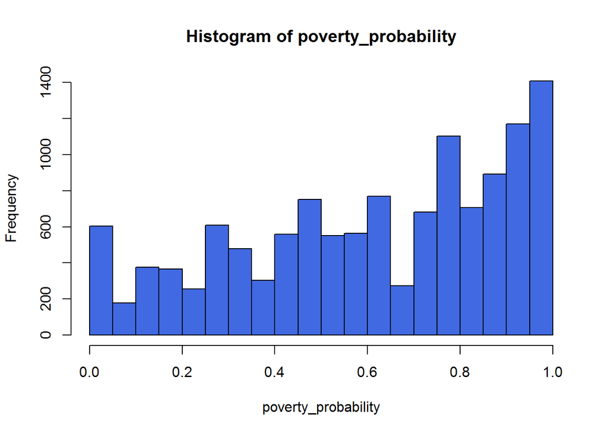

```r
hist(poverty_probability,col = "royalblue")
```

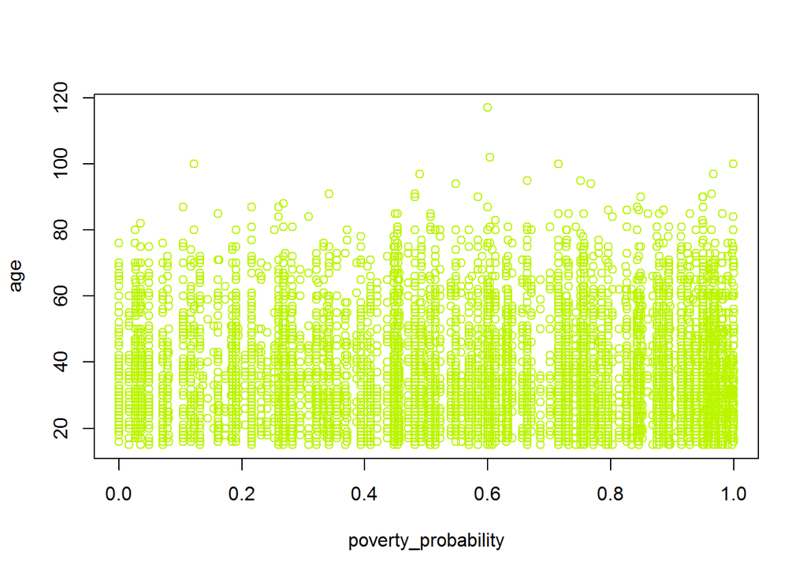

```r
plot(poverty_probability,age,col="#bcf500")
```

#### LITERACY AND POVERTY

```r
table(literacy)
```

```
## literacy
## FALSE  TRUE
##  3281  5119
```

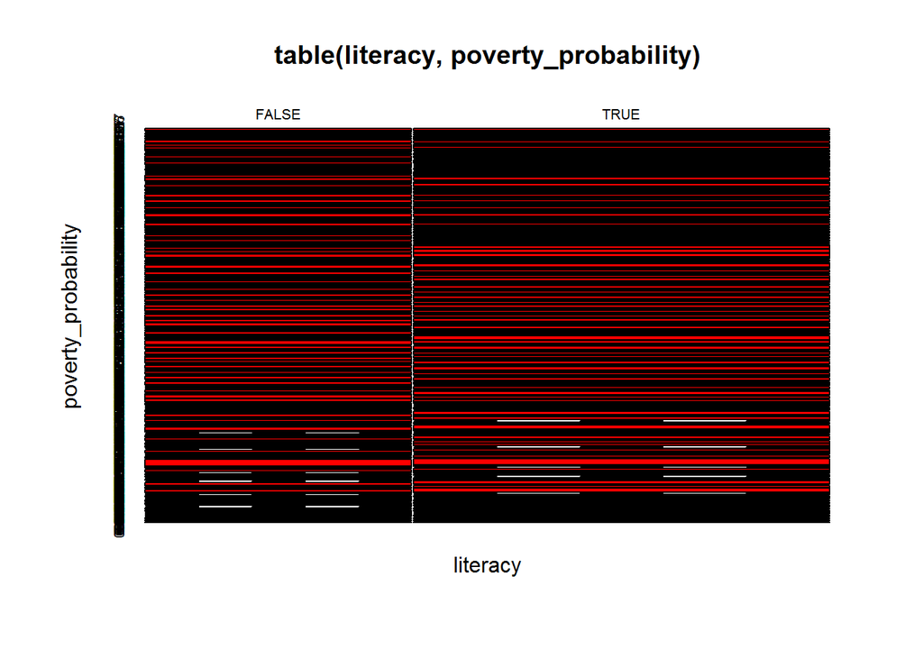

```r
plot(table(literacy,poverty_probability),col="red")
```

#### MARRIED vs POVERTY and URBAN vs RURAL

People who are married are under high poverty rate compared to unmarried.People living in rural areas face more poverty rate compared to urban areas,the dataset contains 5616 number of rural data and 2784 number of urban data.

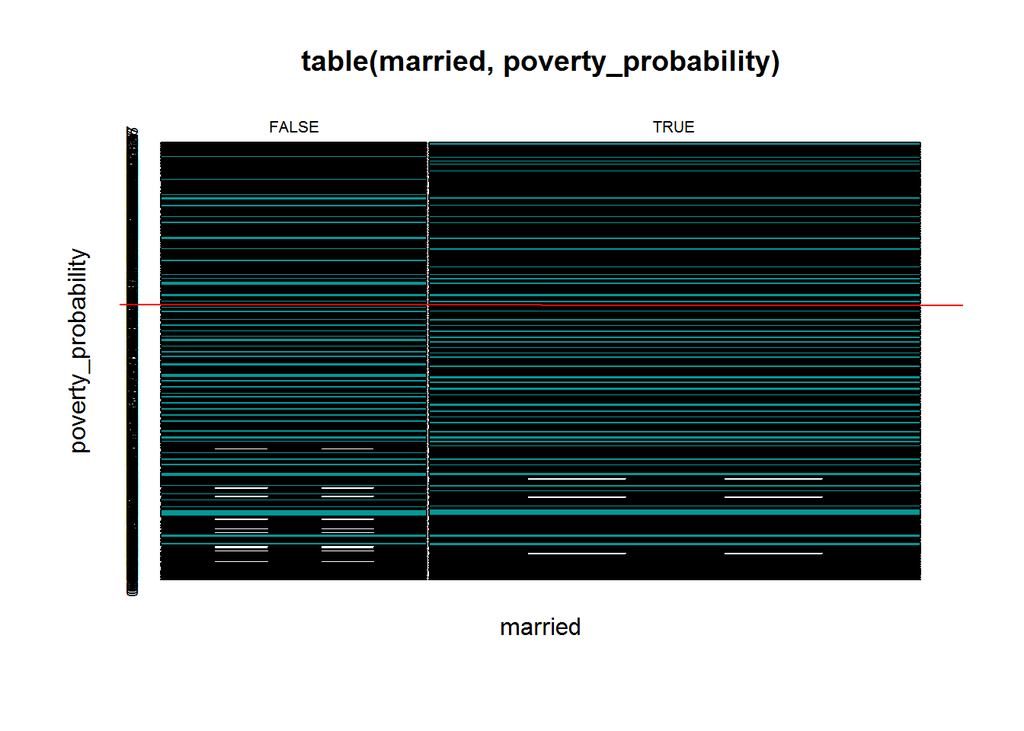

```r
plot(table(married,poverty_probability),col="#009999")
abline(lm(poverty_probability~married),col="#FF0000")
```

```r
#URBAN / RURAL
table(is_urban)
```

```
## is_urban
## FALSE  TRUE
##  5616  2784
```

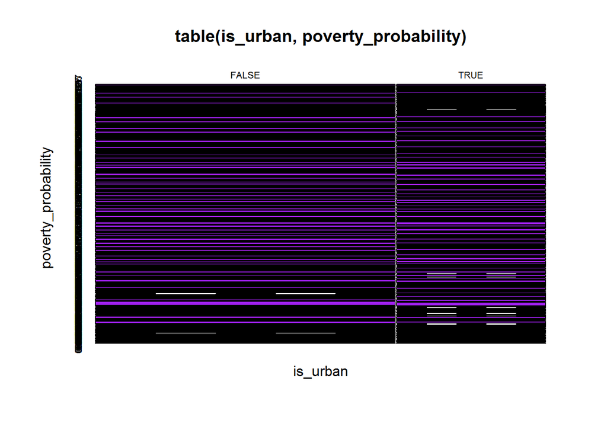

```r
plot(table(is_urban,poverty_probability),col="purple")
```

#### EDUCATION LEVEL OF FEMALE

Female who are illiterate are 1954 in numbers and 2493 are litrate.The number of female’s who are employed are 2029 in number and unemployed are 2418 in number. Many female are in educational level 1 followed by educational level 2

```r
#LITERACY VS FEMALE
litrate<-table(sqldf("select Gender,literacy from dataset where Gender='female'"))
litrate
```

```
##         literacy
## Gender   FALSE TRUE
##              0    0
##   female  1954 2493
##   male       0    0
```

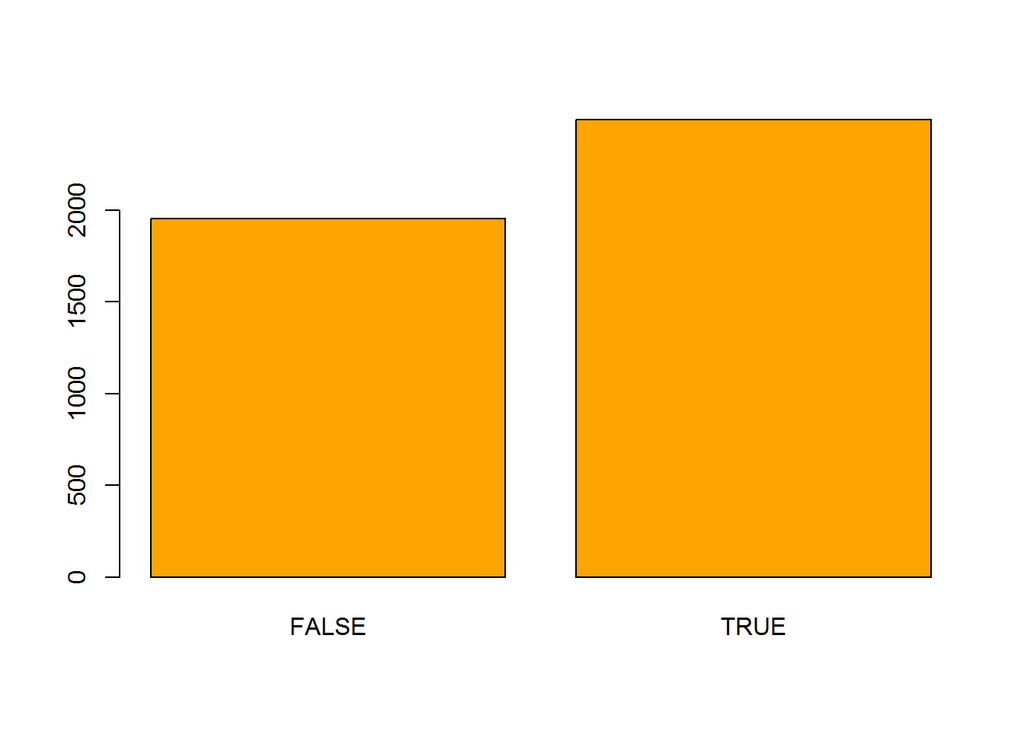

```r
barplot(litrate,col="orange")
```

```r
#EDUCATION LEVEL OF FEMALE
table(sqldf("select Gender,education_level from dataset where Gender='female'"))
```

```
##         education_level
## Gender      0    1    2    3
##             0    0    0    0
##   female 1108 1643 1407  289
##   male      0    0    0    0
```

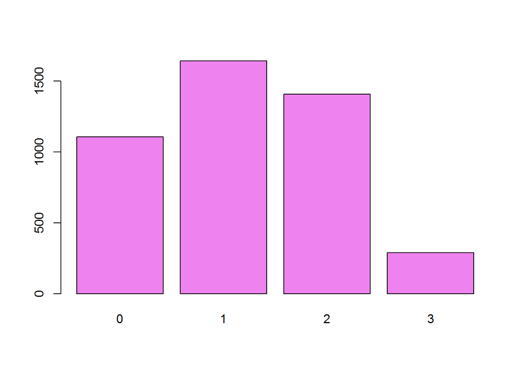

```r
barplot(table(sqldf("select Gender,education_level from dataset where Gender='female'")),col="violet")
```

#### EDUCATION LEVEL OF MALE

The number of men who are illerate are 1121 and the number of men who are literate are 2491. Many Male are in educational level 2 followed by educational level 1

```r
#MALE LITRATE
litrate<-table(sqldf("select Gender,literacy from dataset where Gender='male'"))
litrate
```

```
##         literacy
## Gender   FALSE TRUE
##              0    0
##   female     0    0
##   male    1121 2491
```

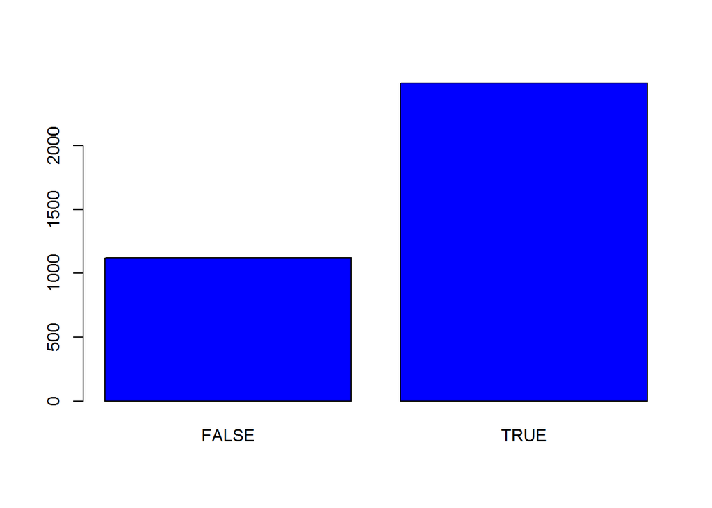

```r
barplot(litrate,col="blue")
```

```r
#EDUCATION LEVEL OF MALE
table(sqldf("select Gender,education_level from dataset where Gender='male'"))
```

```
##         education_level
## Gender      0    1    2    3
##             0    0    0    0
##   female    0    0    0    0
##   male    569 1249 1306  488
```

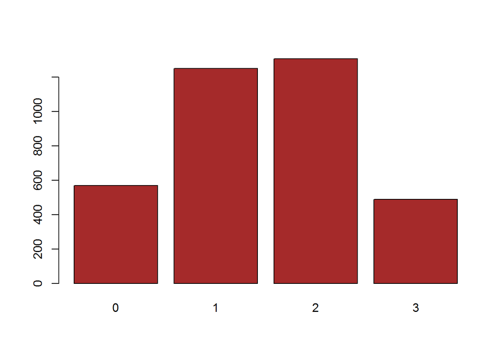

```r
barplot(table(sqldf("select Gender,education_level from dataset where Gender='male'")),col="brown")
```